# Individual differences

In **Pilot 1**, there are 41 subjects who did the curiosity personal trait questionaire. The following analysis will only include these subjects who had personal trait scores.

# 1 Relationship between trait score and slope of curiosity-memory relationship

## 1.1 Outside

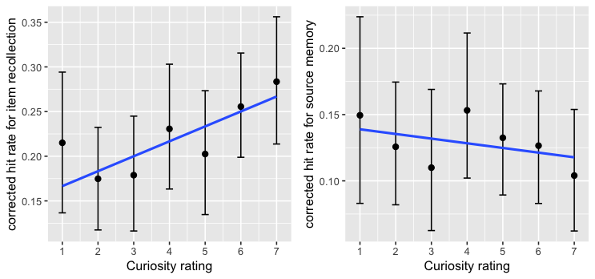

### 1.1.1 Item recollection

#### 1.1.1.1 Correlation with the average score

|  | Model | df | AIC | BIC | logLik | Test | L.Ratio | p-value |
| --- | --- | --- | --- | --- | --- | --- | --- | --- |
| baseline.rating | 1 | 3 | -118.8881 | -108.42132 | 62.44406 |  |  |  |
| rating.intercept | 2 | 4 | -122.5070 | -108.55121 | 65.25348 | 1 vs 2 | 5.618832 | 0.0178 |
| rating.slope | 3 | 6 | -124.2984 | -103.36473 | 68.14918 | 2 vs 3 | 5.791396 | 0.0553 |
| tr.intercept | 4 | 7 | -122.7253 | -98.30275 | 68.36266 | 3 vs 4 | 0.426955 | 0.5135 |
| tr.slope | 5 | 8 | -120.9114 | -92.99986 | 68.45568 | 4 vs 5 | 0.186051 | 0.6662 |

#### 1.1.1.2 Correlation with the PC score

|  | Model | df | AIC | BIC | logLik | Test | L.Ratio | p-value |
| --- | --- | --- | --- | --- | --- | --- | --- | --- |
| baseline.rating | 1 | 3 | -118.8881 | -108.42132 | 62.44406 |  |  |  |
| rating.intercept | 2 | 4 | -122.5070 | -108.55121 | 65.25348 | 1 vs 2 | 5.618832 | 0.0178 |
| rating.slope | 3 | 6 | -124.2984 | -103.36473 | 68.14918 | 2 vs 3 | 5.791396 | 0.0553 |
| PC.intercept | 4 | 7 | -123.1560 | -98.73348 | 68.57802 | 3 vs 4 | 0.857683 | 0.3544 |
| PC.slope | 5 | 8 | -121.2114 | -93.29987 | 68.60569 | 4 vs 5 | 0.055332 | 0.8140 |

#### 1.1.1.3 Correlation with the EC score

|  | Model | df | AIC | BIC | logLik | Test | L.Ratio | p-value |
| --- | --- | --- | --- | --- | --- | --- | --- | --- |
| baseline.rating | 1 | 3 | -118.8881 | -108.42132 | 62.44406 |  |  |  |
| rating.intercept | 2 | 4 | -122.5070 | -108.55121 | 65.25348 | 1 vs 2 | 5.618832 | 0.0178 |
| rating.slope | 3 | 6 | -124.2984 | -103.36473 | 68.14918 | 2 vs 3 | 5.791396 | 0.0553 |
| EC.intercept | 4 | 7 | -122.3607 | -97.93816 | 68.18036 | 3 vs 4 | 0.062370 | 0.8028 |
| EC.slope | 5 | 8 | -121.3980 | -93.48650 | 68.69900 | 4 vs 5 | 1.037275 | 0.3085 |

### 1.1.2 Source memory

#### 1.1.2.1 Correlation with the average score

|  | Model | df | AIC | BIC | logLik | Test | L.Ratio | p-value |
| --- | --- | --- | --- | --- | --- | --- | --- | --- |
| baseline.rating | 1 | 3 | -232.4874 | -222.0206 | 119.2437 |  |  |  |
| rating.intercept | 2 | 4 | -230.9710 | -217.0153 | 119.4855 | 1 vs 2 | 0.4835912 | 0.4868 |
| rating.slope | 3 | 6 | -226.9704 | -206.0368 | 119.4852 | 2 vs 3 | 0.0005518 | 0.9997 |
| tr.intercept | 4 | 7 | -226.1594 | -201.7368 | 120.0797 | 3 vs 4 | 1.1889441 | 0.2755 |
| tr.slope | 5 | 8 | -224.5524 | -196.6409 | 120.2762 | 4 vs 5 | 0.3929654 | 0.5307 |

#### 1.1.2.2 Correlation with the PC score

|  | Model | df | AIC | BIC | logLik | Test | L.Ratio | p-value |
| --- | --- | --- | --- | --- | --- | --- | --- | --- |
| baseline.rating | 1 | 3 | -232.4874 | -222.0206 | 119.2437 |  |  |  |
| rating.intercept | 2 | 4 | -230.9710 | -217.0153 | 119.4855 | 1 vs 2 | 0.4835912 | 0.4868 |
| rating.slope | 3 | 6 | -226.9704 | -206.0368 | 119.4852 | 2 vs 3 | 0.0005518 | 0.9997 |
| PC.intercept | 4 | 7 | -225.8721 | -201.4496 | 119.9361 | 3 vs 4 | 0.9016779 | 0.3423 |
| PC.slope | 5 | 8 | -224.4862 | -196.5747 | 120.2431 | 4 vs 5 | 0.6141099 | 0.4332 |

#### 1.1.2.3 Correlation with the EC score

|  | Model | df | AIC | BIC | logLik | Test | L.Ratio | p-value |
| --- | --- | --- | --- | --- | --- | --- | --- | --- |
| baseline.rating | 1 | 3 | -232.4874 | -222.0206 | 119.2437 |  |  |  |
| rating.intercept | 2 | 4 | -230.9710 | -217.0153 | 119.4855 | 1 vs 2 | 0.4835912 | 0.4868 |
| rating.slope | 3 | 6 | -226.9704 | -206.0368 | 119.4852 | 2 vs 3 | 0.0005518 | 0.9997 |
| EC.intercept | 4 | 7 | -225.9834 | -201.5608 | 119.9917 | 3 vs 4 | 1.0129408 | 0.3142 |
| EC.slope | 5 | 8 | -224.0933 | -196.1818 | 120.0466 | 4 vs 5 | 0.1099146 | 0.7402 |

## 1.2 Inside

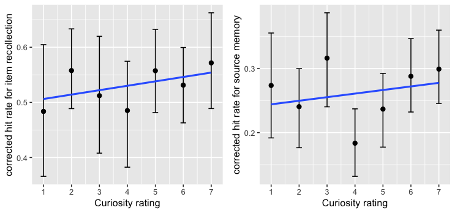

### 1.2.1 Item recollection

#### 1.2.1.1 Correlation with the average score

|  | Model | df | AIC | BIC | logLik | Test | L.Ratio | p-value |
| --- | --- | --- | --- | --- | --- | --- | --- | --- |
| baseline.rating | 1 | 3 | -17.84695 | -7.380140 | 11.92348 |  |  |  |
| rating.intercept | 2 | 4 | -16.87935 | -2.923603 | 12.43968 | 1 vs 2 | 1.032401 | 0.3096 |
| rating.slope | 3 | 6 | -13.86213 | 7.071498 | 12.93106 | 2 vs 3 | 0.982775 | 0.6118 |
| tr.intercept | 4 | 7 | -11.97170 | 12.450869 | 12.98585 | 3 vs 4 | 0.109566 | 0.7406 |
| tr.slope | 5 | 8 | -16.43094 | 11.480564 | 16.21547 | 4 vs 5 | 6.459243 | 0.0110 |

```
                   Value  Std.Error  DF   t-value     p-value
(Intercept)   0.04559218 0.24530516 199  0.185859 0.852744630
CurRating     0.12135108 0.04563901 199  2.658933 0.008476866
GN            0.15879446 0.08400857  39  1.890217 0.066176922
CurRating:GN -0.03950462 0.01553870 199 -2.542338 0.011772483
```

#### 1.2.1.2 Correlation with the PC score

|  | Model | df | AIC | BIC | logLik | Test | L.Ratio | p-value |
| --- | --- | --- | --- | --- | --- | --- | --- | --- |
| baseline.rating | 1 | 3 | -17.84695 | -7.380140 | 11.92348 |  |  |  |
| rating.intercept | 2 | 4 | -16.87935 | -2.923603 | 12.43968 | 1 vs 2 | 1.032401 | 0.3096 |
| rating.slope | 3 | 6 | -13.86213 | 7.071498 | 12.93106 | 2 vs 3 | 0.982775 | 0.6118 |
| PC.intercept | 4 | 7 | -12.70010 | 11.722463 | 13.35005 | 3 vs 4 | 0.837973 | 0.3600 |
| PC.slope | 5 | 8 | -17.34293 | 10.568569 | 16.67147 | 4 vs 5 | 6.642832 | 0.0100 |

```
                   Value  Std.Error  DF     t-value     p-value
(Intercept)  -0.02143884 0.22730687 199 -0.09431671 0.924952476
CurRating     0.11501438 0.04198712 199  2.73927785 0.006716704
PC            0.18064172 0.07695854  39  2.34726026 0.024082270
CurRating:PC -0.03705070 0.01413893 199 -2.62047357 0.009458334
```

#### 1.2.1.3 Correlation with the EC score

|  | Model | df | AIC | BIC | logLik | Test | L.Ratio | p-value |
| --- | --- | --- | --- | --- | --- | --- | --- | --- |
| baseline.rating | 1 | 3 | -17.84695 | -7.380140 | 11.92348 |  |  |  |
| rating.intercept | 2 | 4 | -16.87935 | -2.923603 | 12.43968 | 1 vs 2 | 1.032401 | 0.3096 |
| rating.slope | 3 | 6 | -13.86213 | 7.071498 | 12.93106 | 2 vs 3 | 0.982775 | 0.6118 |
| EC.intercept | 4 | 7 | -11.95988 | 12.462680 | 12.97994 | 3 vs 4 | 0.097756 | 0.7545 |
| EC.slope | 5 | 8 | -13.83390 | 14.077600 | 14.91695 | 4 vs 5 | 3.874018 | 0.0490 |

```
                   Value  Std.Error  DF   t-value   p-value
(Intercept)   0.26787870 0.22049131 199  1.214917 0.2258372
CurRating     0.08678052 0.04128545 199  2.101964 0.0368145
EC            0.08244413 0.07592402  39  1.085877 0.2842000
CurRating:EC -0.02781632 0.01413116 199 -1.968438 0.0504062
```

### 1.2.2 Source memory

#### 1.2.2.1 Correlation with the average score

|  | Model | df | AIC | BIC | logLik | Test | L.Ratio | p-value |
| --- | --- | --- | --- | --- | --- | --- | --- | --- |
| baseline.rating | 1 | 3 | -122.5635 | -112.09672 | 64.28177 |  |  |  |
| rating.intercept | 2 | 4 | -121.9097 | -107.95393 | 64.95484 | 1 vs 2 | 1.3461452 | 0.2460 |
| rating.slope | 3 | 6 | -120.2308 | -99.29716 | 66.11539 | 2 vs 3 | 2.3211109 | 0.3133 |
| tr.intercept | 4 | 7 | -118.2446 | -93.82202 | 66.12229 | 3 vs 4 | 0.0138012 | 0.9065 |
| tr.slope | 5 | 8 | -117.1638 | -89.25230 | 66.58190 | 4 vs 5 | 0.9192124 | 0.3377 |

#### 1.2.2.2 Correlation with the PC score

|  | Model | df | AIC | BIC | logLik | Test | L.Ratio | p-value |
| --- | --- | --- | --- | --- | --- | --- | --- | --- |
| baseline.rating | 1 | 3 | -122.5635 | -112.09672 | 64.28177 |  |  |  |
| rating.intercept | 2 | 4 | -121.9097 | -107.95393 | 64.95484 | 1 vs 2 | 1.3461452 | 0.2460 |
| rating.slope | 3 | 6 | -120.2308 | -99.29716 | 66.11539 | 2 vs 3 | 2.3211109 | 0.3133 |
| PC.intercept | 4 | 7 | -118.7426 | -94.32008 | 66.37132 | 3 vs 4 | 0.5118555 | 0.4743 |
| PC.slope | 5 | 8 | -116.7772 | -88.86575 | 66.38863 | 4 vs 5 | 0.0346119 | 0.8524 |

```
                  Value   Std.Error  DF   t-value   p-value
(Intercept) 0.155581064 0.100706736 200 1.5448923 0.1239531
CurRating   0.008491664 0.007354032 200 1.1546950 0.2495931
PC          0.023095219 0.032333733  39 0.7142763 0.4793099
```

#### 1.2.2.3 Correlation with the EC score

|  | Model | df | AIC | BIC | logLik | Test | L.Ratio | p-value |
| --- | --- | --- | --- | --- | --- | --- | --- | --- |
| baseline.rating | 1 | 3 | -122.5635 | -112.09672 | 64.28177 |  |  |  |
| rating.intercept | 2 | 4 | -121.9097 | -107.95393 | 64.95484 | 1 vs 2 | 1.346145 | 0.2460 |
| rating.slope | 3 | 6 | -120.2308 | -99.29716 | 66.11539 | 2 vs 3 | 2.321111 | 0.3133 |
| EC.intercept | 4 | 7 | -119.1206 | -94.69803 | 66.56030 | 3 vs 4 | 0.889806 | 0.3455 |
| EC.slope | 5 | 8 | -119.4942 | -91.58271 | 67.74711 | 4 vs 5 | 2.373622 | 0.1234 |

# 2 Relationship between trait score and curiosity ratings

## 2.1 Across all the rooms

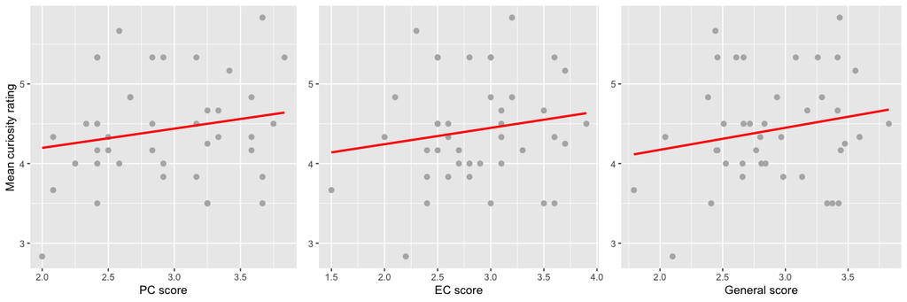

```r
cor.test(trait.ratings$meanCurRating, trait.ratings$PC, method = "pearson")
```

```
    Pearson's product-moment correlation

data:  trait.ratings$meanCurRating and trait.ratings$PC
t = 1.1936, df = 39, p-value = 0.2398
alternative hypothesis: true correlation is not equal to 0
95 percent confidence interval:
 -0.1272648  0.4683367
sample estimates:
     cor
0.187736
```

```r
cor.test(trait.ratings$meanCurRating, trait.ratings$EC, method = "pearson")
```

```
    Pearson's product-moment correlation

data:  trait.ratings$meanCurRating and trait.ratings$EC
t = 1.0136, df = 39, p-value = 0.317
alternative hypothesis: true correlation is not equal to 0
95 percent confidence interval:
 -0.1550854  0.4458826
sample estimates:
     cor
0.160209
```

```r
cor.test(trait.ratings$meanCurRating, trait.ratings$GN, method = "pearson")
```

```
    Pearson's product-moment correlation

data:  trait.ratings$meanCurRating and trait.ratings$GN
t = 1.2316, df = 39, p-value = 0.2255
alternative hypothesis: true correlation is not equal to 0
95 percent confidence interval:
 -0.1213936  0.4729792
sample estimates:
      cor
0.1934828
```

## 2.2 Only for the *novel* rooms

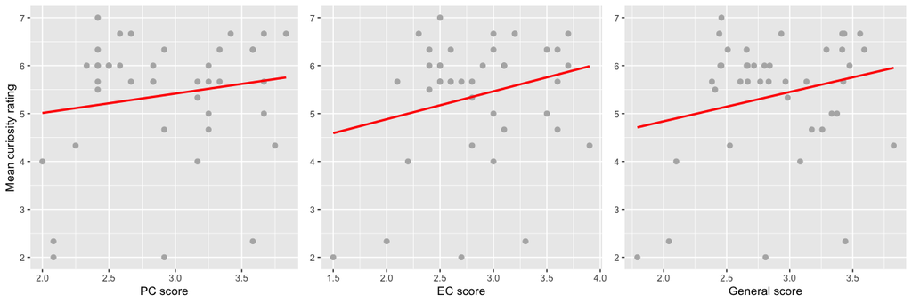

```
    Pearson's product-moment correlation

data:  trait.ratings.novel$meanCurRating and trait.ratings.novel$PC
t = 1.0311, df = 39, p-value = 0.3089
alternative hypothesis: true correlation is not equal to 0
95 percent confidence interval:
 -0.1523898  0.4480918
sample estimates:
      cor
0.1628978


    Pearson's product-moment correlation

data:  trait.ratings.novel$meanCurRating and trait.ratings.novel$EC
t = 1.5156, df = 39, p-value = 0.1377
alternative hypothesis: true correlation is not equal to 0
95 percent confidence interval:
 -0.0774208  0.5067301
sample estimates:
      cor
0.2358472


    Pearson's product-moment correlation

data:  trait.ratings.novel$meanCurRating and trait.ratings.novel$GN
t = 1.4213, df = 39, p-value = 0.1632
alternative hypothesis: true correlation is not equal to 0
95 percent confidence interval:
 -0.09201643  0.49572239
sample estimates:
      cor
0.2219162
```

# 3 Relationship between trait score and memory performance

Here *memory performance* refers to the average corrected hit rate for “seen” response for items and average corrected hit rate for source memory.

## 3.1 Outside

### 3.1.1 Item recollection

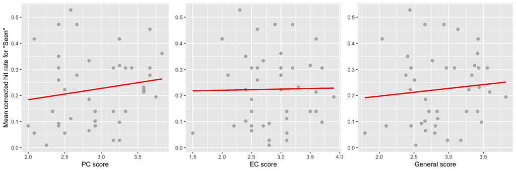

```
    Pearson's product-moment correlation

data:  outside.hit.rate.trait$meanSAcc and outside.hit.rate.trait$PC
t = 1.0242, df = 39, p-value = 0.3121
alternative hypothesis: true correlation is not equal to 0
95 percent confidence interval:
 -0.1534507  0.4472232
sample estimates:
      cor
0.1618401


    Pearson's product-moment correlation

data:  outside.hit.rate.trait$meanSAcc and outside.hit.rate.trait$EC
t = 0.10391, df = 39, p-value = 0.9178
alternative hypothesis: true correlation is not equal to 0
95 percent confidence interval:
 -0.2925110  0.3226357
sample estimates:
       cor
0.01663662


    Pearson's product-moment correlation

data:  outside.hit.rate.trait$meanSAcc and outside.hit.rate.trait$GN
t = 0.6214, df = 39, p-value = 0.538
alternative hypothesis: true correlation is not equal to 0
95 percent confidence interval:
 -0.2151914  0.3946431
sample estimates:
       cor
0.09901413
```

### 3.1.2 Source memory

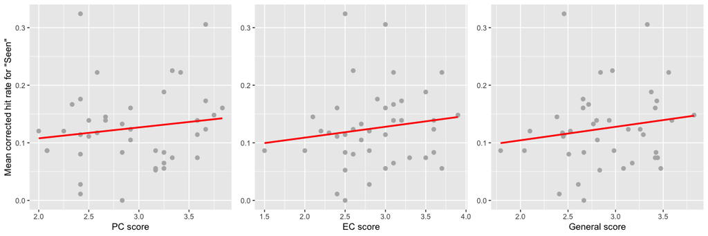

```
    Pearson's product-moment correlation

data:  outside.hit.rate.trait$meanSrcAcc and outside.hit.rate.trait$PC
t = 0.91368, df = 39, p-value = 0.3665
alternative hypothesis: true correlation is not equal to 0
95 percent confidence interval:
 -0.1704777  0.4331256
sample estimates:
      cor
0.1447654


    Pearson's product-moment correlation

data:  outside.hit.rate.trait$meanSrcAcc and outside.hit.rate.trait$EC
t = 0.9154, df = 39, p-value = 0.3656
alternative hypothesis: true correlation is not equal to 0
95 percent confidence interval:
 -0.1702132  0.4333469
sample estimates:
     cor
0.145032


    Pearson's product-moment correlation

data:  outside.hit.rate.trait$meanSrcAcc and outside.hit.rate.trait$GN
t = 1.02, df = 39, p-value = 0.314
alternative hypothesis: true correlation is not equal to 0
95 percent confidence interval:
 -0.1541028  0.4466887
sample estimates:
      cor
0.1611896
```

## 3.2 Inside

### 3.2.1 Item recollection

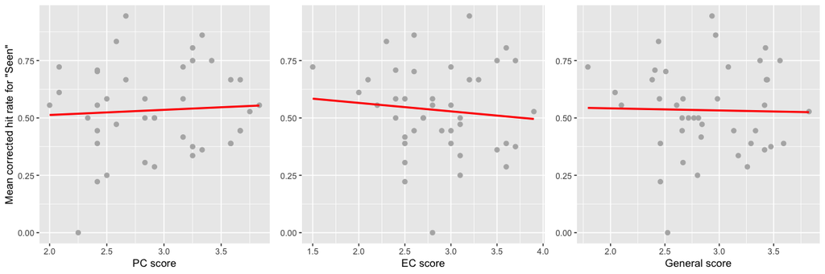

```
    Pearson's product-moment correlation

data:  inside.hit.rate.trait$meanSAcc and inside.hit.rate.trait$PC
t = 0.37942, df = 39, p-value = 0.7064
alternative hypothesis: true correlation is not equal to 0
95 percent confidence interval:
 -0.2517027  0.3615488
sample estimates:
       cor
0.06064379


    Pearson's product-moment correlation

data:  inside.hit.rate.trait$meanSAcc and inside.hit.rate.trait$EC
t = -0.62839, df = 39, p-value = 0.5334
alternative hypothesis: true correlation is not equal to 0
95 percent confidence interval:
 -0.3955832  0.2141287
sample estimates:
       cor
-0.1001171


    Pearson's product-moment correlation

data:  inside.hit.rate.trait$meanSAcc and inside.hit.rate.trait$GN
t = -0.13892, df = 39, p-value = 0.8902
alternative hypothesis: true correlation is not equal to 0
95 percent confidence interval:
 -0.3276487  0.2873767
sample estimates:
        cor
-0.02224006
```

### 3.2.2 Source memory

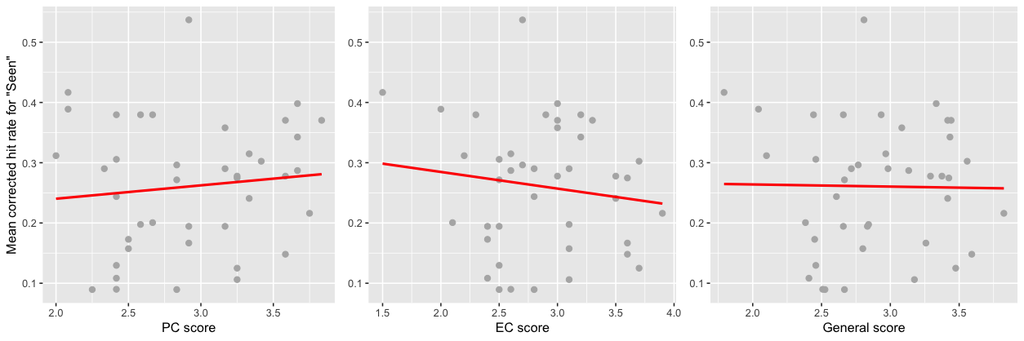

```
    Pearson's product-moment correlation

data:  inside.hit.rate.trait$meanSrcAcc and inside.hit.rate.trait$PC
t = 0.68129, df = 39, p-value = 0.4997
alternative hypothesis: true correlation is not equal to 0
95 percent confidence interval:
 -0.2060762  0.4026656
sample estimates:
      cor
0.1084499


    Pearson's product-moment correlation

data:  inside.hit.rate.trait$meanSrcAcc and inside.hit.rate.trait$EC
t = -0.85565, df = 39, p-value = 0.3974
alternative hypothesis: true correlation is not equal to 0
95 percent confidence interval:
 -0.4256215  0.1793965
sample estimates:
      cor
-0.135746


    Pearson's product-moment correlation

data:  inside.hit.rate.trait$meanSrcAcc and inside.hit.rate.trait$GN
t = -0.097525, df = 39, p-value = 0.9228
alternative hypothesis: true correlation is not equal to 0
95 percent confidence interval:
 -0.3217195  0.2934456
sample estimates:
        cor
-0.01561452
```

# 4 Relationship between trait score and memory performance within *Novel* rooms

Here *memory performance* refers to the average corrected hit rate for “seen” response for items and average corrected hit rate for source memory.

## 4.1 Outside

### 4.1.1 Item recollection

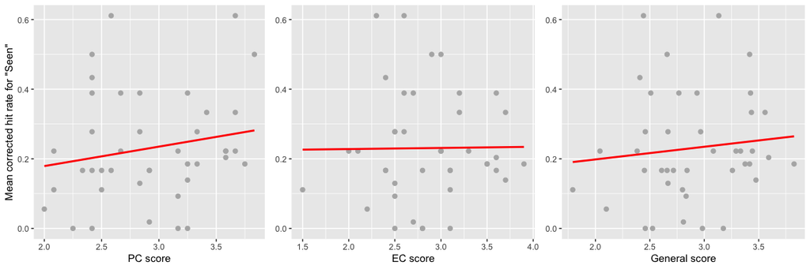

```
    Pearson's product-moment correlation

data:  outside.hit.rate.trait.novel$meanSAcc and outside.hit.rate.trait.novel$PC
t = 1.1846, df = 39, p-value = 0.2434
alternative hypothesis: true correlation is not equal to 0
95 percent confidence interval:
 -0.1286693  0.4672213
sample estimates:
      cor
0.1863581


    Pearson's product-moment correlation

data:  outside.hit.rate.trait.novel$meanSAcc and outside.hit.rate.trait.novel$EC
t = 0.067705, df = 39, p-value = 0.9464
alternative hypothesis: true correlation is not equal to 0
95 percent confidence interval:
 -0.2978029  0.3174325
sample estimates:
       cor
0.01084077


    Pearson's product-moment correlation

data:  outside.hit.rate.trait.novel$meanSAcc and outside.hit.rate.trait.novel$GN
t = 0.68716, df = 39, p-value = 0.496
alternative hypothesis: true correlation is not equal to 0
95 percent confidence interval:
 -0.2051805  0.4034488
sample estimates:
     cor
0.109374
```

### 4.1.2 Source memory

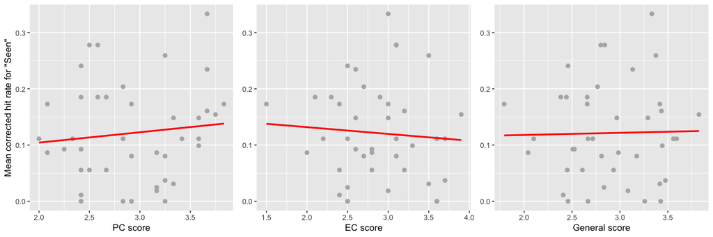

```
    Pearson's product-moment correlation

data:  outside.hit.rate.trait.novel$meanSrcAcc and outside.hit.rate.trait.novel$PC
t = 0.70331, df = 39, p-value = 0.486
alternative hypothesis: true correlation is not equal to 0
95 percent confidence interval:
 -0.2027182  0.4055976
sample estimates:
      cor
0.1119118


    Pearson's product-moment correlation

data:  outside.hit.rate.trait.novel$meanSrcAcc and outside.hit.rate.trait.novel$EC
t = -0.46134, df = 39, p-value = 0.6471
alternative hypothesis: true correlation is not equal to 0
95 percent confidence interval:
 -0.3728720  0.2394037
sample estimates:
        cor
-0.07367294


    Pearson's product-moment correlation

data:  outside.hit.rate.trait.novel$meanSrcAcc and outside.hit.rate.trait.novel$GN
t = 0.1308, df = 39, p-value = 0.8966
alternative hypothesis: true correlation is not equal to 0
95 percent confidence interval:
 -0.2885690  0.3264876
sample estimates:
       cor
0.02094056
```

## 4.2 Inside

### 4.2.1 Item recollection

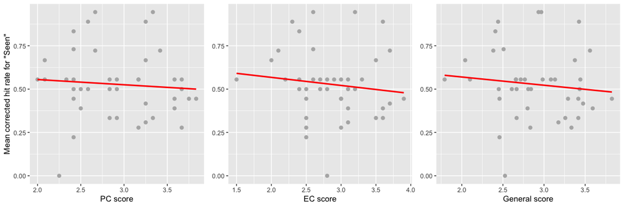

```
    Pearson's product-moment correlation

data:  inside.hit.rate.trait.novel$meanSAcc and inside.hit.rate.trait.novel$PC
t = -0.49409, df = 39, p-value = 0.624
alternative hypothesis: true correlation is not equal to 0
95 percent confidence interval:
 -0.3773646  0.2344690
sample estimates:
        cor
-0.07887073


    Pearson's product-moment correlation

data:  inside.hit.rate.trait.novel$meanSAcc and inside.hit.rate.trait.novel$EC
t = -0.77184, df = 39, p-value = 0.4449
alternative hypothesis: true correlation is not equal to 0
95 percent confidence interval:
 -0.4146619  0.1922458
sample estimates:
       cor
-0.1226593


    Pearson's product-moment correlation

data:  inside.hit.rate.trait.novel$meanSAcc and inside.hit.rate.trait.novel$GN
t = -0.70496, df = 39, p-value = 0.485
alternative hypothesis: true correlation is not equal to 0
95 percent confidence interval:
 -0.4058170  0.2024664
sample estimates:
       cor
-0.1121711
```

### 4.2.2 Source memory

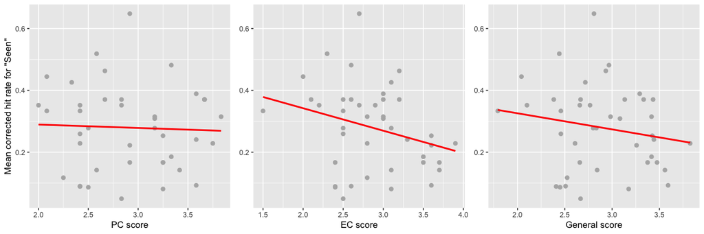

```
    Pearson's product-moment correlation

data:  inside.hit.rate.trait.novel$meanSrcAcc and inside.hit.rate.trait.novel$PC
t = -0.26159, df = 39, p-value = 0.795
alternative hypothesis: true correlation is not equal to 0
95 percent confidence interval:
 -0.3450593  0.2692657
sample estimates:
        cor
-0.04185168


    Pearson's product-moment correlation

data:  inside.hit.rate.trait.novel$meanSrcAcc and inside.hit.rate.trait.novel$EC
t = -1.8208, df = 39, p-value = 0.07632
alternative hypothesis: true correlation is not equal to 0
95 percent confidence interval:
 -0.54096945  0.03036183
sample estimates:
       cor
-0.2799031


    Pearson's product-moment correlation

data:  inside.hit.rate.trait.novel$meanSrcAcc and inside.hit.rate.trait.novel$GN
t = -1.1387, df = 39, p-value = 0.2618
alternative hypothesis: true correlation is not equal to 0
95 percent confidence interval:
 -0.4615631  0.1357572
sample estimates:
       cor
-0.1793855
```

# 5 Relationship between trait score and curiosity ratings between *Familiar* and *Novel* rooms

## 5.1 See whether the curiosity ratings are significantly different between *novel* and *familiar* rooms

The average curiosity rating for the *novel* rooms is 5.39 (SD = $\pm$ 1.3).

The average curiosity rating for the *familiar* rooms is 3.46 (SD = $\pm$ 1.49).

```
    One Sample t-test

data:  outside.hit.rate.trait.diff$diffRating
t = 5.0341, df = 40, p-value = 1.062e-05
alternative hypothesis: true mean is not equal to 0
95 percent confidence interval:
 1.155687 2.706102
sample estimates:
mean of x
 1.930894
```

## 5.2 See whether the difference in curiosity ratings are significantly correlated with trait scores

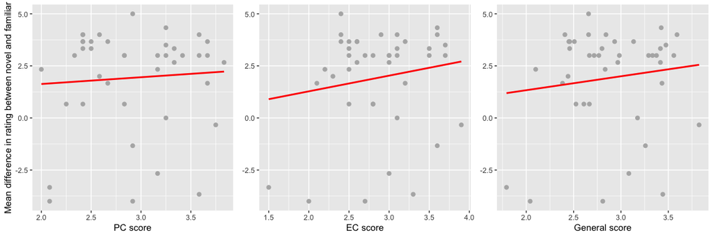

```
    Pearson's product-moment correlation

data:  outside.hit.rate.trait.diff$diffRating and outside.hit.rate.trait.diff$PC
t = 0.43463, df = 39, p-value = 0.6662
alternative hypothesis: true correlation is not equal to 0
95 percent confidence interval:
 -0.2434214  0.3691931
sample estimates:
       cor
0.06942848


    Pearson's product-moment correlation

data:  outside.hit.rate.trait.diff$diffRating and outside.hit.rate.trait.diff$EC
t = 1.0252, df = 39, p-value = 0.3116
alternative hypothesis: true correlation is not equal to 0
95 percent confidence interval:
 -0.1532923  0.4473530
sample estimates:
     cor
0.161998


    Pearson's product-moment correlation

data:  outside.hit.rate.trait.diff$diffRating and outside.hit.rate.trait.diff$GN
t = 0.81166, df = 39, p-value = 0.4219
alternative hypothesis: true correlation is not equal to 0
95 percent confidence interval:
 -0.1861452  0.4198874
sample estimates:
      cor
0.1288863
```

### 5.2.1 Looking at the trait-rating correlation separately for the *novel* and *familiar* rooms

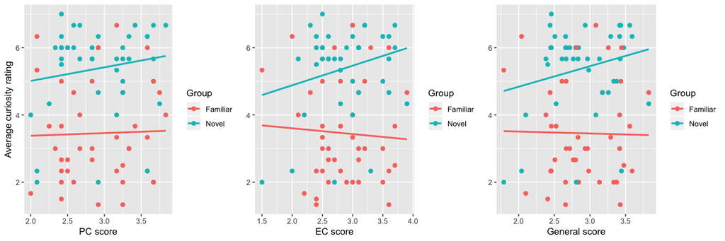

# 6 Relationship between trait score and performance differences between *Familiar* and *Novel* rooms

Here *performance difference* refers to difference in item recollection and source memory between the *novel* and *familiar* rooms (*novel* - *familiar*).

## 6.1 Outside

### 6.1.1 Item recollection

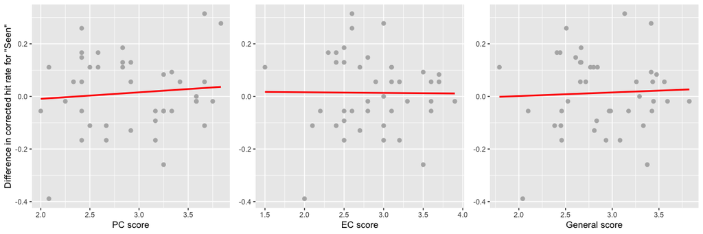

### 6.1.2 Source memory

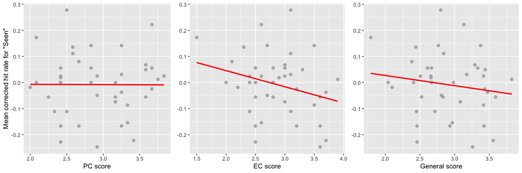

```
    Pearson's product-moment correlation

data:  outside.hit.rate.trait.diff$diffSrcAcc and outside.hit.rate.trait.diff$PC
t = -0.027936, df = 39, p-value = 0.9779
alternative hypothesis: true correlation is not equal to 0
95 percent confidence interval:
 -0.3116948  0.3035950
sample estimates:
         cor
-0.004473299


    Pearson's product-moment correlation

data:  outside.hit.rate.trait.diff$diffSrcAcc and outside.hit.rate.trait.diff$EC
t = -1.7719, df = 39, p-value = 0.08422
alternative hypothesis: true correlation is not equal to 0
95 percent confidence interval:
 -0.53562964  0.03787149
sample estimates:
       cor
-0.2729593


    Pearson's product-moment correlation

data:  outside.hit.rate.trait.diff$diffSrcAcc and outside.hit.rate.trait.diff$GN
t = -0.97843, df = 39, p-value = 0.3339
alternative hypothesis: true correlation is not equal to 0
95 percent confidence interval:
 -0.4414168  0.1605071
sample estimates:
       cor
-0.1547867
```

## 6.2 Inside

### 6.2.1 Item recollection

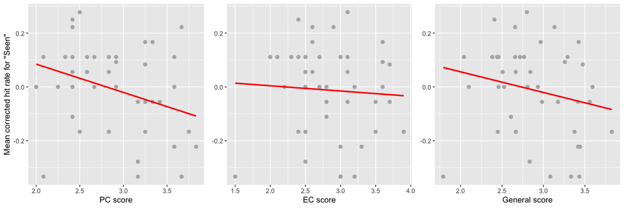

```
    Pearson's product-moment correlation

data:  inside.hit.rate.trait.diff$diffSAcc and inside.hit.rate.trait.diff$PC
t = -2.1312, df = 39, p-value = 0.03943
alternative hypothesis: true correlation is not equal to 0
95 percent confidence interval:
 -0.57362473 -0.01701063
sample estimates:
       cor
-0.3229709


    Pearson's product-moment correlation

data:  inside.hit.rate.trait.diff$diffSAcc and inside.hit.rate.trait.diff$EC
t = -0.37592, df = 39, p-value = 0.709
alternative hypothesis: true correlation is not equal to 0
95 percent confidence interval:
 -0.3610625  0.2522265
sample estimates:
        cor
-0.06008649


    Pearson's product-moment correlation

data:  inside.hit.rate.trait.diff$diffSAcc and inside.hit.rate.trait.diff$GN
t = -1.3587, df = 39, p-value = 0.182
alternative hypothesis: true correlation is not equal to 0
95 percent confidence interval:
 -0.4883088  0.1017063
sample estimates:
       cor
-0.2125963
```

### 6.2.2 Source memory

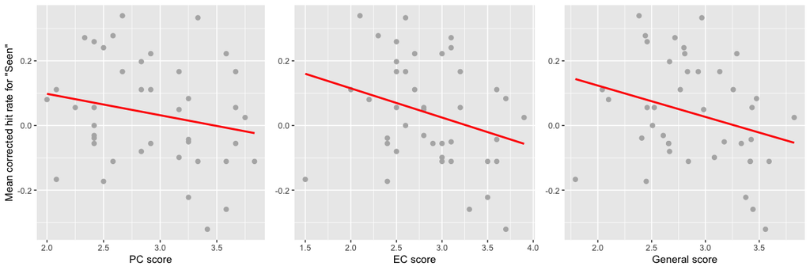

```
    Pearson's product-moment correlation

data:  inside.hit.rate.trait.diff$diffSrcAcc and inside.hit.rate.trait.diff$PC
t = -1.3467, df = 39, p-value = 0.1858
alternative hypothesis: true correlation is not equal to 0
95 percent confidence interval:
 -0.4868803  0.1035606
sample estimates:
       cor
-0.2108063


    Pearson's product-moment correlation

data:  inside.hit.rate.trait.diff$diffSrcAcc and inside.hit.rate.trait.diff$EC
t = -1.883, df = 39, p-value = 0.06717
alternative hypothesis: true correlation is not equal to 0
95 percent confidence interval:
 -0.54769358  0.02081267
sample estimates:
       cor
-0.2886862


    Pearson's product-moment correlation

data:  inside.hit.rate.trait.diff$diffSrcAcc and inside.hit.rate.trait.diff$GN
t = -1.8071, df = 39, p-value = 0.07847
alternative hypothesis: true correlation is not equal to 0
95 percent confidence interval:
 -0.53947887  0.03246462
sample estimates:
      cor
-0.277962
```